# Assessment 1.1

Nike 4660593

04/09/2021

# RMarkdown editing

*R Markdown documents provide quick, reproducible reporting from R. You write your document in markdown and embed executable R code chunks with the knitr syntax. You can update your document at any time by re-knitting the code chunks. You can then convert your document into several common formats.*

[insert](https://rmarkdown.rstudio.com/lesson-8.html)

```r
library(tidyverse)
library(knitr)
library(skimr)
library(ggpubr)
```

*6. Insert an R chunk and create a variable with this dataset*

```r
fastfood<-read.csv('https://raw.githubusercontent.com/rfordatascience/tidytuesday/master/data/2018/2018-09-04/fastfood_calories.csv', header = TRUE)
```

*7. Display the first 10 rows of the dataset. Use Help to see how you can do this with `head()` function.*

```r
data <-fastfood
head(data, 10)
```

```
##     X restaurant                                      item calories cal_fat
## 1   1  Mcdonalds          Artisan Grilled Chicken Sandwich      380      60
## 2   2  Mcdonalds            Single Bacon Smokehouse Burger      840     410
## 3   3  Mcdonalds            Double Bacon Smokehouse Burger     1130     600
## 4   4  Mcdonalds Grilled Bacon Smokehouse Chicken Sandwich      750     280
## 5   5  Mcdonalds  Crispy Bacon Smokehouse Chicken Sandwich      920     410
## 6   6  Mcdonalds                                   Big Mac      540     250
## 7   7  Mcdonalds                              Cheeseburger      300     100
## 8   8  Mcdonalds                  Classic Chicken Sandwich      510     210
## 9   9  Mcdonalds                       Double Cheeseburger      430     190
## 10 10  Mcdonalds       Double Quarter Pounder® with Cheese      770     400
##    total_fat sat_fat trans_fat cholesterol sodium total_carb fiber sugar
## 1          7       2       0.0          95   1110         44     3    11
## 2         45      17       1.5         130   1580         62     2    18
## 3         67      27       3.0         220   1920         63     3    18
```

[output cut: 18 more lines]

```r
kable(data[1:10, 1:5])
```

| X | restaurant | item | calories | cal_fat |
| --- | --- | --- | --- | --- |
| 1 | Mcdonalds | Artisan Grilled Chicken Sandwich | 380 | 60 |
| 2 | Mcdonalds | Single Bacon Smokehouse Burger | 840 | 410 |
| 3 | Mcdonalds | Double Bacon Smokehouse Burger | 1130 | 600 |
| 4 | Mcdonalds | Grilled Bacon Smokehouse Chicken Sandwich | 750 | 280 |
| 5 | Mcdonalds | Crispy Bacon Smokehouse Chicken Sandwich | 920 | 410 |
| 6 | Mcdonalds | Big Mac | 540 | 250 |
| 7 | Mcdonalds | Cheeseburger | 300 | 100 |
| 8 | Mcdonalds | Classic Chicken Sandwich | 510 | 210 |
| 9 | Mcdonalds | Double Cheeseburger | 430 | 190 |
| 10 | Mcdonalds | Double Quarter Pounder® with Cheese | 770 | 400 |

*8. Display the observations that has more than 1000 calories*

```r
highcal<- data %>%
  filter(calories >1000)
highcal
```

```
##      X  restaurant                                             item calories
## 1    3   Mcdonalds                   Double Bacon Smokehouse Burger     1130
## 2   38   Mcdonalds       10 piece Buttermilk Crispy Chicken Tenders     1210
## 3   39   Mcdonalds       12 piece Buttermilk Crispy Chicken Tenders     1510
## 4   40   Mcdonalds       20 piece Buttermilk Crispy Chicken Tenders     2430
## 5   45   Mcdonalds                       40 piece Chicken McNuggets     1770
## 6   48   Mcdonalds 10 piece Sweet N' Spicy Honey BBQ Glazed Tenders     1600
## 7   99       Sonic   Super Sonic Bacon Double Cheeseburger (w/mayo)     1280
## 8  100       Sonic       Super Sonic Double Cheeseburger W/ Mustard     1120
## 9  101       Sonic       Super Sonic Double Cheeseburger W/ Ketchup     1130
## 10 102       Sonic          Super Sonic Double Cheeseburger W/ Mayo     1220
## 11 103       Sonic         Super Sonic Jalapeno Double Cheeseburger     1120
## 12 116       Sonic Garlic Parmesan Dunked Ultimate Chicken Sandwich     1350
## 13 122       Sonic        4 Piece Super Crunch Chicken Strip Dinner     1080
## 14 123       Sonic        5 Piece Super Crunch Chicken Strip Dinner     1190
```

[output cut: 72 more lines]

*9. Save observations with more than 40 in total_fat and more than 80 in total_carb in a new variable called `dont_eat_this`*

```r
dont_eat_this<- data %>%
  filter(total_fat >40 & total_carb>80)
```

*10. Using the initial dataset variable, display observations from restaurant Mcdonalds*

```r
filter(data, restaurant == "Mcdonalds")
```

```
##     X restaurant                                              item calories
## 1   1  Mcdonalds                  Artisan Grilled Chicken Sandwich      380
## 2   2  Mcdonalds                    Single Bacon Smokehouse Burger      840
## 3   3  Mcdonalds                    Double Bacon Smokehouse Burger     1130
## 4   4  Mcdonalds         Grilled Bacon Smokehouse Chicken Sandwich      750
## 5   5  Mcdonalds          Crispy Bacon Smokehouse Chicken Sandwich      920
## 6   6  Mcdonalds                                           Big Mac      540
## 7   7  Mcdonalds                                      Cheeseburger      300
## 8   8  Mcdonalds                          Classic Chicken Sandwich      510
## 9   9  Mcdonalds                               Double Cheeseburger      430
## 10 10  Mcdonalds               Double Quarter Pounder® with Cheese      770
## 11 11  Mcdonalds                                     Filet-O-Fish®      380
## 12 12  Mcdonalds                       Garlic White Cheddar Burger      620
## 13 13  Mcdonalds     Grilled Garlic White Cheddar Chicken Sandwich      530
## 14 14  Mcdonalds      Crispy Garlic White Cheddar Chicken Sandwich      700
```

[output cut: 159 more lines]

*11. Display the types of variables in the dataset using `skimr` package*

```r
skim(data)
```

Data summary

| Name | data |
| --- | --- |
| Number of rows | 515 |
| Number of columns | 18 |
| _______________________ |  |
| Column type frequency: |  |
| factor | 3 |
| numeric | 15 |
| ________________________ |  |
| Group variables | None |

**Variable type: factor**

| skim_variable | n_missing | complete_rate | ordered | n_unique | top_counts |
| --- | --- | --- | --- | --- | --- |
| restaurant | 0 | 1 | FALSE | 8 | Tac: 115, Sub: 96, Bur: 70, Mcd: 57 |
| item | 0 | 1 | FALSE | 505 | Cri: 3, Gri: 3, Che: 2, Chi: 2 |
| salad | 0 | 1 | FALSE | 1 | Oth: 515 |

**Variable type: numeric**

| skim_variable | n_missing | complete_rate | mean | sd | p0 | p25 | p50 | p75 | p100 | hist |
| --- | --- | --- | --- | --- | --- | --- | --- | --- | --- | --- |
| X | 0 | 1.00 | 258.00 | 148.81 | 1 | 129.5 | 258.0 | 386.5 | 515 | ▇▇▇▇▇ |
| calories | 0 | 1.00 | 530.91 | 282.44 | 20 | 330.0 | 490.0 | 690.0 | 2430 | ▇▆▁▁▁ |
| cal_fat | 0 | 1.00 | 238.81 | 166.41 | 0 | 120.0 | 210.0 | 310.0 | 1270 | ▇▃▁▁▁ |
| total_fat | 0 | 1.00 | 26.59 | 18.41 | 0 | 14.0 | 23.0 | 35.0 | 141 | ▇▃▁▁▁ |
| sat_fat | 0 | 1.00 | 8.15 | 6.42 | 0 | 4.0 | 7.0 | 11.0 | 47 | ▇▃▁▁▁ |
| trans_fat | 0 | 1.00 | 0.47 | 0.84 | 0 | 0.0 | 0.0 | 1.0 | 8 | ▇▁▁▁▁ |
| cholesterol | 0 | 1.00 | 72.46 | 63.16 | 0 | 35.0 | 60.0 | 95.0 | 805 | ▇▁▁▁▁ |
| sodium | 0 | 1.00 | 1246.74 | 689.95 | 15 | 800.0 | 1110.0 | 1550.0 | 6080 | ▇▆▁▁▁ |
| total_carb | 0 | 1.00 | 45.66 | 24.88 | 0 | 28.5 | 44.0 | 57.0 | 156 | ▅▇▂▁▁ |
| fiber | 12 | 0.98 | 4.14 | 3.04 | 0 | 2.0 | 3.0 | 5.0 | 17 | ▇▅▂▁▁ |
| sugar | 0 | 1.00 | 7.26 | 6.76 | 0 | 3.0 | 6.0 | 9.0 | 87 | ▇▁▁▁▁ |
| protein | 1 | 1.00 | 27.89 | 17.68 | 1 | 16.0 | 24.5 | 36.0 | 186 | ▇▂▁▁▁ |
| vit_a | 214 | 0.58 | 18.86 | 31.38 | 0 | 4.0 | 10.0 | 20.0 | 180 | ▇▁▁▁▁ |
| vit_c | 210 | 0.59 | 20.17 | 30.59 | 0 | 4.0 | 10.0 | 30.0 | 400 | ▇▁▁▁▁ |
| calcium | 210 | 0.59 | 24.85 | 25.52 | 0 | 8.0 | 20.0 | 30.0 | 290 | ▇▁▁▁▁ |

*12. Show the count of observations for each restaurant.*

```r
data %>%
  count(restaurant, sort = TRUE) %>%
  kable()
```

| restaurant | n |
| --- | --- |
| Taco Bell | 115 |
| Subway | 96 |
| Burger King | 70 |
| Mcdonalds | 57 |
| Arbys | 55 |
| Sonic | 53 |
| Dairy Queen | 42 |
| Chick Fil-A | 27 |

*13. Using grouppings (group_by()), summarise and display the average number of calories for each restaurant.*

```r
dat <- data %>%
  group_by(restaurant) %>%
  summarise(average_calories = mean(calories)) %>%
  ungroup() %>%
  arrange(desc(average_calories)) %>%
  kable()
dat
```

[output not shown]

```r
data1 <- data %>%
  group_by(restaurant) %>%
  mutate(average_calories = mean(calories)) %>%
  ungroup()
```

*15. Display the data vis of total fat per each type of restaurant. Write a narration (2-3 sentences) why you believe this type of data viz presents such information best.*

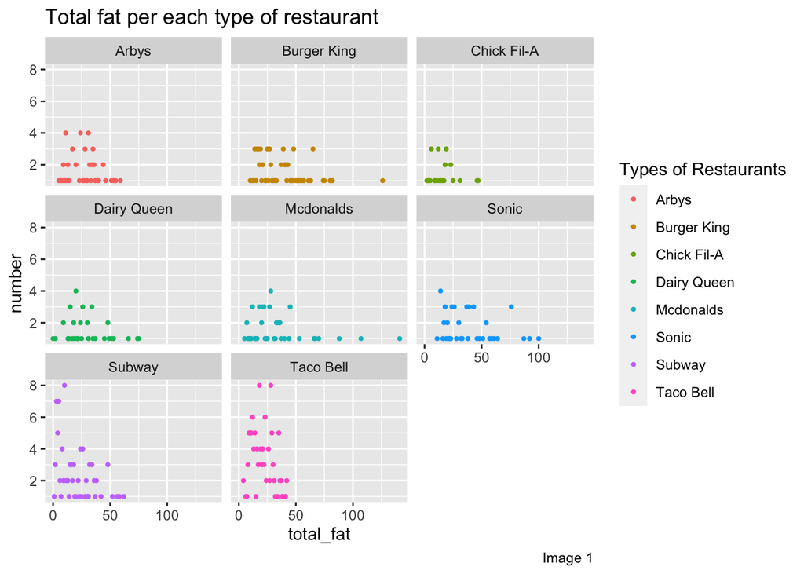

```r
daa <- data1 %>%
  group_by(restaurant,total_fat) %>%
  tally()

ggplot(daa, aes(total_fat,n,colour = restaurant)) +
  geom_point(size = 0.8) +
  facet_wrap(~restaurant)+
  labs(x="total_fat", y="number", colour="Types of Restaurants",
       title="Total fat per each type of restaurant", caption="Image 1")
```

```r
#The dataset contains disscrete numbers, and it has multiple class for the variable 'restaurant', so i used geom_point and facet_wrap.
```

*16. Add a variable to the dataset, which calculates the maximum total fat per type of restaurant and call it `max_total_fat`*

```r
data2 <- data %>%
  group_by(restaurant) %>%
  mutate(max_total_fat = max(total_fat)) %>%
  ungroup()
```

*17. Use observations for Mcdonalds to plot sugar variable against protein with `geom_point()`*

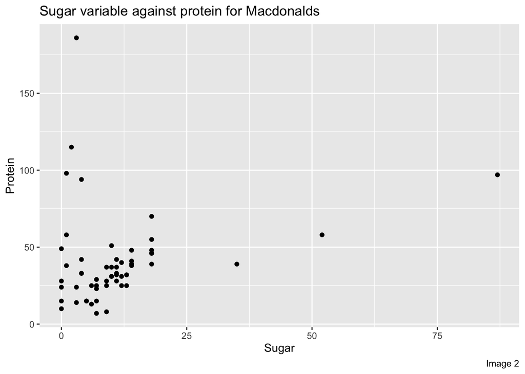

```r
data3<- data %>%
  filter(restaurant == "Mcdonalds") %>%
  ggplot(aes(sugar,protein)) +
  geom_point() +
  labs(x="Sugar", y="Protein",
       title="Sugar variable against protein for Macdonalds", caption="Image 2")
data3
```

*8. Identify variable(s) which should be factors and transform their type into a factor variable.*

```r
datt <- data %>%
  mutate(
    protein_type = cut_number(protein, n =3,labels=c("low", "med", "high") )
    )
class(datt$protein_type)
```

```
## [1] "factor"
```

*19. Create two new variables:Read about `cut_number()` function using Help and add a new variable to the dataset `calories_type`. Use `calories` variable for `cut_number()` function to split it into 3 categories `n=3`, add labels `labels=c("low", "med", "high")` and make the dataset ordered.*

```r
data4 <- data %>%
  mutate(
    calories_type = cut_number(calories, n =3,labels=c("low", "med", "high") )
    )
data5 <-data4[order(data4$calories_type),]

class(data5$calories_type)
```

```
## [1] "factor"
```

*20. Create a dataviz that shows the distribution of `calories_type` in food items for each type of restaurant. Think carefully about the choice of data viz. Use facets, coordinates and theme layers to make your data viz visually appealing and meaningful. Use factors related data viz functions.*

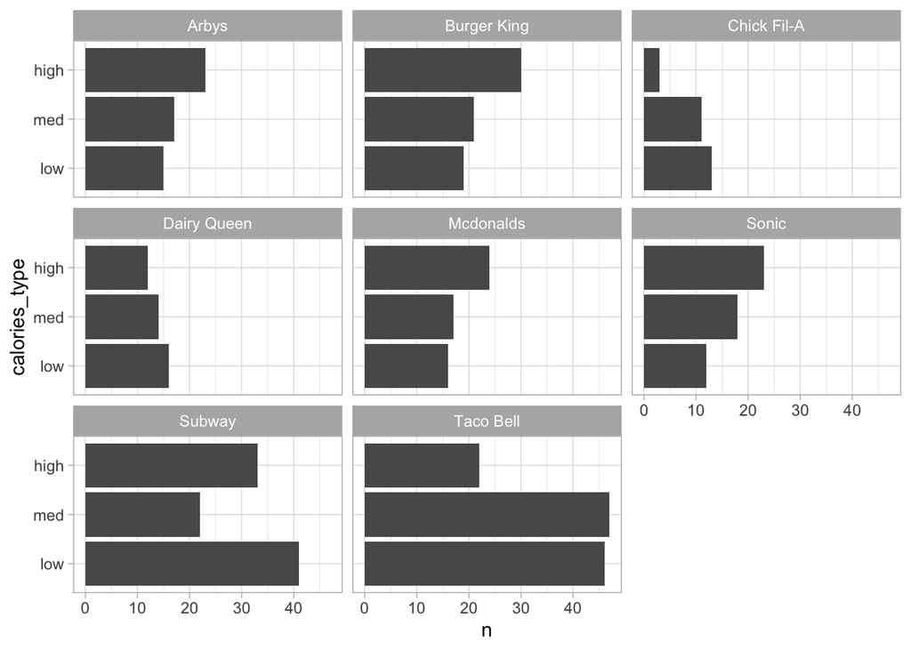

```r
data6 <- data5 %>%
  group_by(calories_type, restaurant) %>%
  tally()

ggplot(data6, aes(calories_type,n)) +
  geom_col() +
  coord_flip() +
  facet_wrap(~restaurant)+
  theme_light()
```

*21. The second variable should show the percentage of `trans_fat` in `total_fat`. Add the variable to the dataset and call it `trans_fat_percent`. Do not forget to save the updated dataset.*

```r
data4 %>%
  mutate(trans_fat_percent = trans_fat/total_fat)
```

```
##       X  restaurant
## 1     1   Mcdonalds
## 2     2   Mcdonalds
## 3     3   Mcdonalds
## 4     4   Mcdonalds
## 5     5   Mcdonalds
## 6     6   Mcdonalds
## 7     7   Mcdonalds
## 8     8   Mcdonalds
## 9     9   Mcdonalds
## 10   10   Mcdonalds
## 11   11   Mcdonalds
## 12   12   Mcdonalds
## 13   13   Mcdonalds
## 14   14   Mcdonalds
```

[output cut: 2049 more lines]

*22. Create a dataviz that shows the distribution of `trans_fat` in food items for each type of restaurant. Think carefully about the choice of data viz. Use facets, coordinates and theme layers to make your data viz visually appealing and meaningful.*

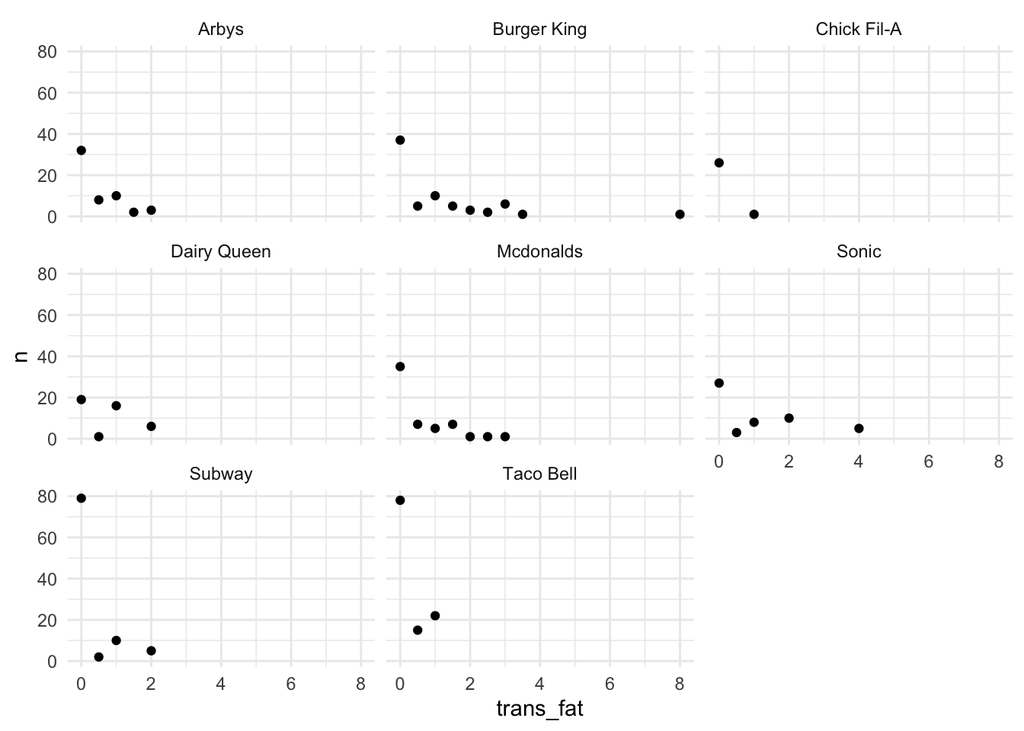

```r
data7 <- data4 %>%
  group_by(restaurant,trans_fat) %>%
  tally()

ggplot(data7, aes(trans_fat,n)) +
  geom_point() +
  facet_wrap(~restaurant)+
  theme_minimal()
```

*23. Calculate and show the average (mean) `total_fat` for each type of restaurant. No need to save it as a variable.*

```r
data4 %>%
  group_by(restaurant) %>%
  summarise(avg_total_fat = mean(total_fat)) %>%
  ungroup() %>%
  arrange(desc(avg_total_fat)) %>%
  kable()
```

| restaurant | avg_total_fat |
| --- | --- |
| Sonic | 37.64151 |
| Burger King | 36.81429 |
| Mcdonalds | 31.80702 |
| Dairy Queen | 28.85714 |
| Arbys | 26.98182 |
| Taco Bell | 20.89565 |
| Subway | 18.47917 |
| Chick Fil-A | 16.14815 |

*24. And create a dataviz that allow to compare different restaurants on this variable (`total_fat`). You can present it on one dataviz (= no facets).*

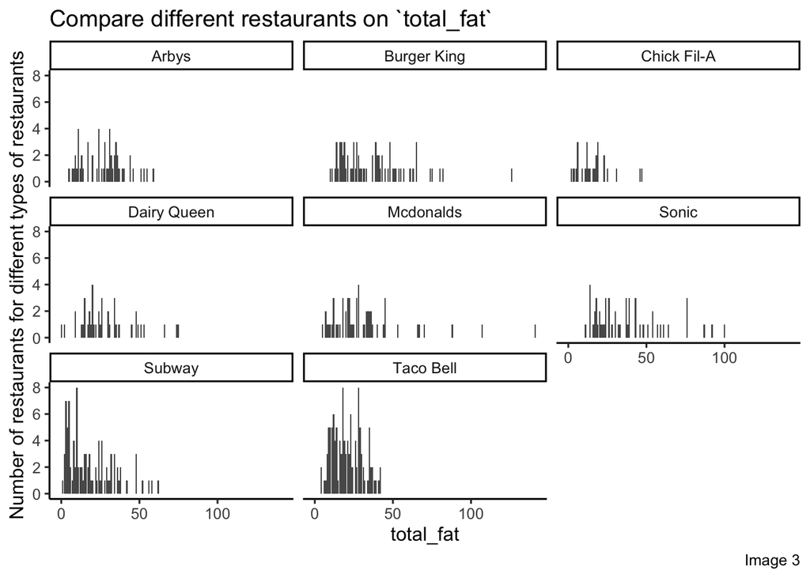

```r
data7 <- data4 %>%
  group_by(restaurant,total_fat) %>%
  tally()

ggplot(data7, aes(total_fat,n)) +
  geom_col() +
  facet_wrap(~restaurant)+
  labs(x="total_fat", y="Number of restaurants for different types of restaurants",
       title="Compare different restaurants on `total_fat`", caption="Image 3")+
  theme_classic2()
```